# TP bioregionalisation avec la diversité beta

Boris Leroy, UMR BOREA, Muséum National d’Histoire Naturelle

# Chargez les packages

```r
library(bioregion)
library(sf)
library(vegan)
library(rnaturalearth)
```

# 1. Chargement des données

```r
# Matrice de présence-absence (sites x espèces)
comat <- readRDS("./data/araignees/araignees_wp_100km_comat.RDS")

# Grille des sites
sites <- readRDS("./data/araignees/araignees_wp_100km_sites.RDS")

dim(comat)
```

```
## [1] 1483 3835
```

## Calcul de la richesse spécifique et filtrage des données

Les lignes de la matrice sont les sites et les colonnes les espèces : la somme d’une ligne donne le nombre d’espèces présentes dans le site (la richesse), la somme d’une colonne donne le nombre de sites occupés par l’espèce (l’occurrence).

```r
richness <- rowSums(comat)

head(richness)
```

```
## 401 473 475 546 547 549
##   6   3   1   6   8   1
```

## Inspection des données : richesse et effort d’échantillonnage

```r
head(sites)
```

```
## Simple feature collection with 6 features and 3 fields
## Geometry type: POLYGON
## Dimension:     XY
## Bounding box:  xmin: 4300000 ymin: 6100000 xmax: 4700000 ymax: 6400000
## Projected CRS: ETRS89-extended / LAEA Europe
##   Site richesse n_occurrences                       geometry
## 1  401        6             6 POLYGON ((4400000 6300000, ...
## 2  473        3             3 POLYGON ((4300000 6200000, ...
## 3  475        1             1 POLYGON ((4500000 6200000, ...
## 4  546        6            14 POLYGON ((4300000 6100000, ...
## 5  547        8            14 POLYGON ((4400000 6100000, ...
## 6  549        1             1 POLYGON ((4600000 6100000, ...
```

```r
# Vérification : la richesse calculée correspond à celle fournie
sites$richness <- richness[match(sites$Site,
                                 names(richness))]
```

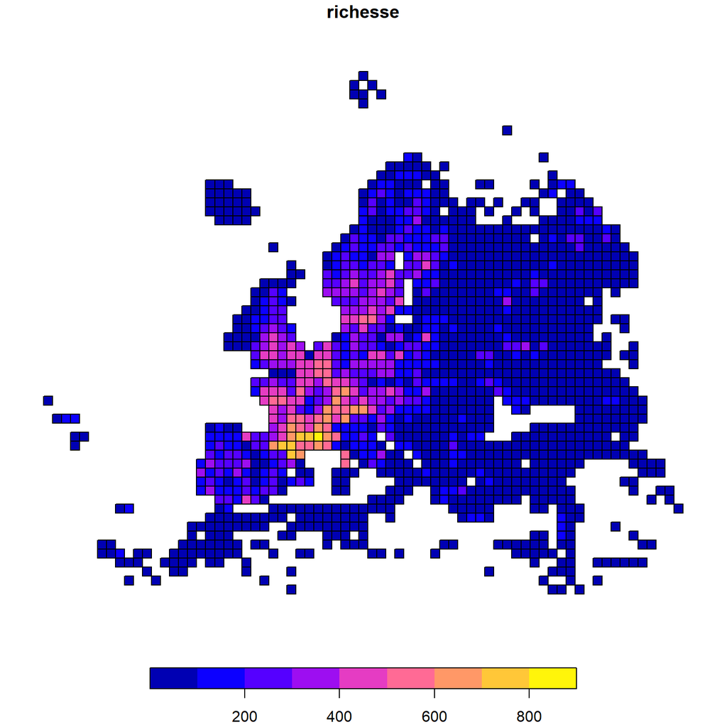

```r
# Carte de la richesse spécifique
plot(sites["richesse"])
```

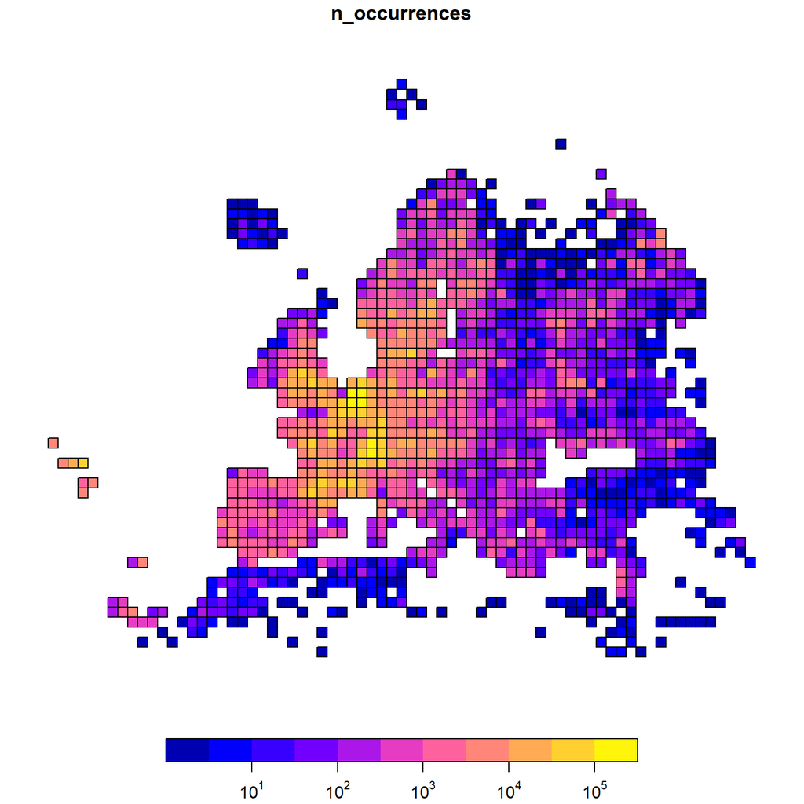

```r
# Carte de l'effort d'échantillonnage (échelle log, car très asymétrique)
plot(sites["n_occurrences"], logz = TRUE)
```

**Question** Que constatez-vous ?

Il y a un biais spatial de l’effort d’échantillonage vers l’Europe de l’Ouest, avec moins de données en Europe de l’est. Certains pays (France, Benelux, UK, Allemagne, Scandinavie) sont surreprésentés. En France, la richesse spécifique augmente vers la région Méditerranéenne.

## Filtrez le jeu de données

```r
# Version filtrée : on retire les cellules de moins de 50 espèces, trop
# peu échantillonnées pour avoir une composition fiable
comat_50 <- comat[richness >= 50, ]
# Les espèces qui n'étaient présentes que dans les cellules retirées
comat_50 <- comat_50[, colSums(comat_50) > 0]

sites_50 <- sites[sites$richness >= 50, ]

dim(comat)
```

```
## [1] 1483 3835
```

```r
dim(comat_50)
```

```
## [1]  742 3593
```

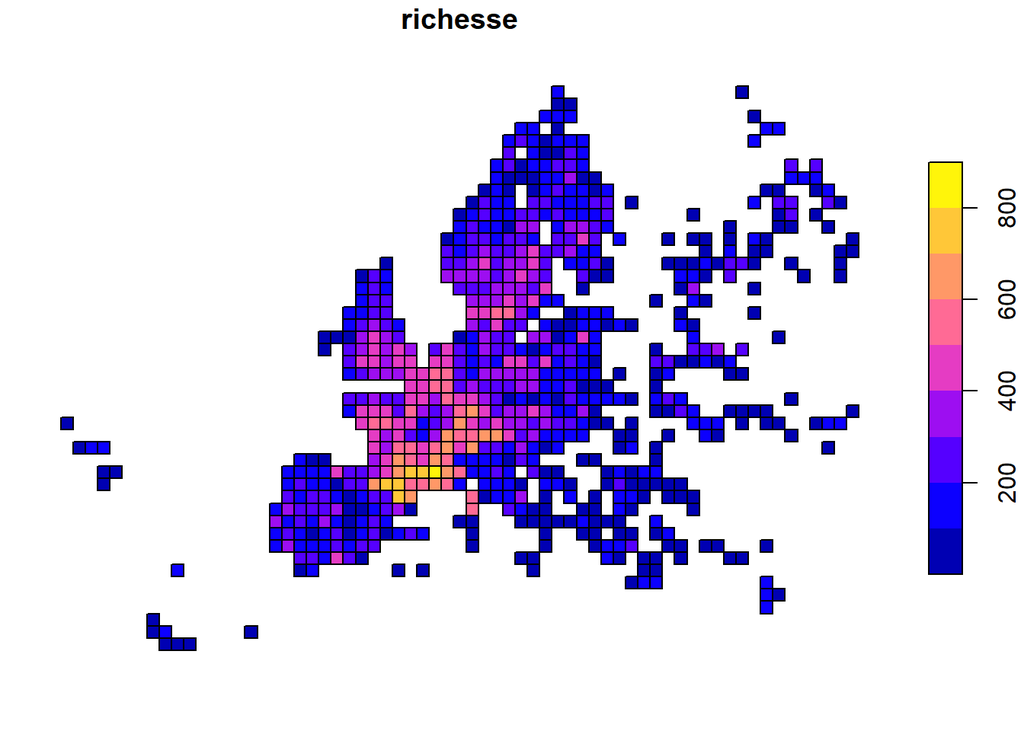

```r
plot(sites_50["richesse"])
```

# 2. Calcul des distances entre bassins avec l’indice ßsim [3]

```r
dist_araignees <- dissimilarity(comat,
                                metric = "Simpson")

dist_araignees_50 <- dissimilarity(comat_50,
                                   metric = "Simpson")
```

# 3. Visualisation des distances entres sites

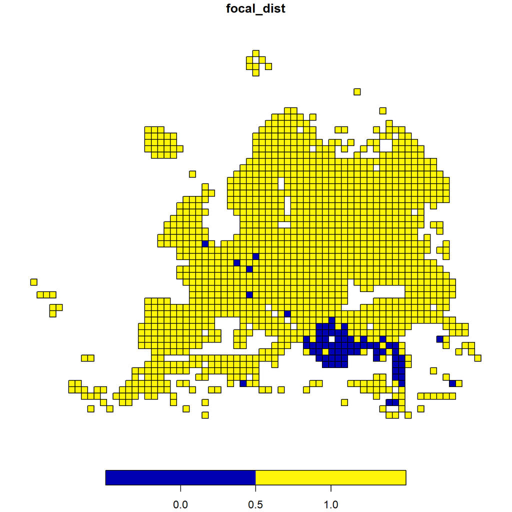

```r
matrix_dist <- net_to_mat(dist_araignees,
                          weight = TRUE, squared = TRUE, symmetrical = TRUE)

focal_cell <- sample(sites$Site, 1)

# Distances entre la cellule focale et toutes les cellules
sites$focal_dist <- matrix_dist[as.character(focal_cell),
                                as.character(sites$Site)]

plot(sites["focal_dist"])
```

# 4. Faire la classification ascendante hiérarchique

```r
hclust_araignees <- hclu_hierarclust(dist_araignees,
                                     optimal_tree_method = "ihct",
                                     ihct_n_workers = 4)
```

```
## Building the iterative hierarchical consensus tree... Note that this process can take time especially if you have a lot of sites.
```

```
## Randomized trees for groups of 200 sites or more are built on 4 processes.
```

```
##
## Final tree has a 0.6456 cophenetic correlation coefficient with the initial dissimilarity matrix
```

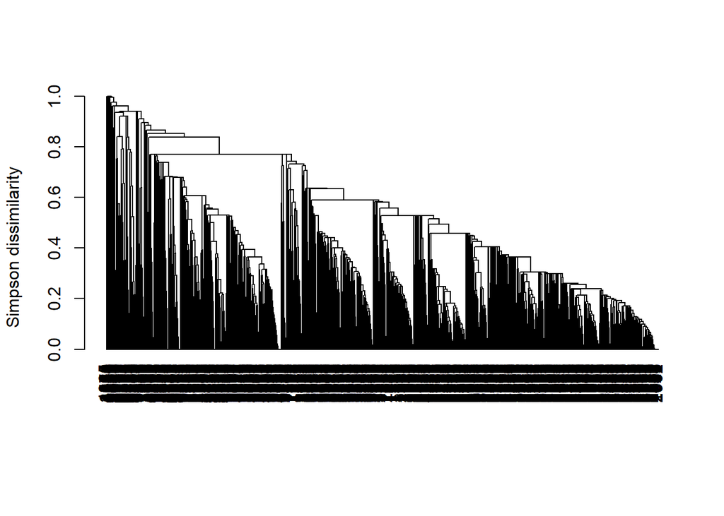

```r
plot(hclust_araignees)
```

```r
hclust_araignees_50 <- hclu_hierarclust(dist_araignees_50,
                                        optimal_tree_method = "ihct",
                                        ihct_n_workers = 4)
```

```
## Building the iterative hierarchical consensus tree... Note that this process can take time especially if you have a lot of sites.
```

```
## Randomized trees for groups of 200 sites or more are built on 4 processes.
```

```
##
## Final tree has a 0.7027 cophenetic correlation coefficient with the initial dissimilarity matrix
```

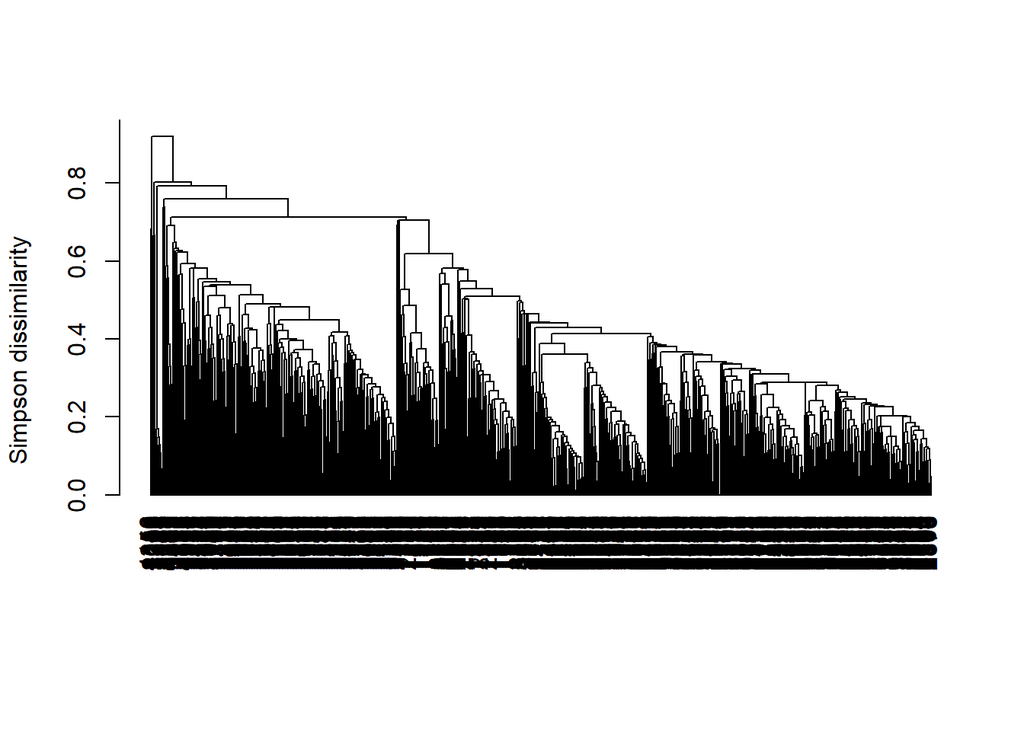

```r
plot(hclust_araignees_50)
```

**Question** Qu’est-ce que l’arbre nous dit des valeurs de dissimilarité ? Regardez les valeurs de dissimilarité sur l’arbre, et réfléchissez à ce qu’elles signifient.

Les valeurs de dissimilarité sont comprises entre 0 et 0.8 environ, avec beaucoup de sites reliés entre 0.4 et 0.5. Cela signifie qu’il y a un pool d’espèces communes entre tous les sites, à hauteur de 20% de la diversité beta environ, et que de nombreux sites partagent près de 50% de leur composition en espèces.

# 5. Evaluer la qualité de la classification consensus

```r
hclust_araignees
```

```
## Clustering results for algorithm : hclu_hierarclust
##  (hierarchical clustering based on a dissimilarity matrix)
##  - Number of sites:  1483
##  - Name of dissimilarity metric:  Simpson
##  - Tree construction method:  average
##  - Randomization of the dissimilarity matrix:  yes, number of trials 100
##  - Method to compute the final tree:  Iterative hierarchical consensus tree
##  - Cophenetic correlation coefficient:  0.646
## Clustering procedure incomplete - no clusters yet
```

```r
hclust_araignees_50
```

```
## Clustering results for algorithm : hclu_hierarclust
##  (hierarchical clustering based on a dissimilarity matrix)
##  - Number of sites:  742
##  - Name of dissimilarity metric:  Simpson
##  - Tree construction method:  average
##  - Randomization of the dissimilarity matrix:  yes, number of trials 100
##  - Method to compute the final tree:  Iterative hierarchical consensus tree
##  - Cophenetic correlation coefficient:  0.703
## Clustering procedure incomplete - no clusters yet
```

**Question** Quelles conséquences sur la qualité de l’arbre de filtrer le jeu de données ?

Les sites à faible richesse abaissent la qualité de l’arbre. Ils créent de l’incertitude, car ils sont difficiles à classer et compromettent la topologie de l’arbre.

# 6. Rechercher la hauteur à laquelle couper l’arbre

## Etape 1

```r
hclust_araignees <- cut_tree(hclust_araignees,
                            n_clust = 2:50)
summary(hclust_araignees)
```

[output not shown]

```r
hclust_araignees_50 <- cut_tree(hclust_araignees_50,
                               n_clust = 2:50)
summary(hclust_araignees_50)
```

```
##
## Summary of clustering results
## =============================
##
## Algorithm:  hclu_hierarclust
## Number of sites:  742
## Number of bioregionalizations:  49
## Hierarchical clustering: Yes
##
## Bioregionalization 1: K_2
## -------------------------
## Total clusters:  2
## Top 2 clusters by size:
##   Cluster 1: 740 items
##   Cluster 2: 2 items
##
## Bioregionalization 2: K_3
## -------------------------
## Total clusters:  3
## Top 3 clusters by size:
##   Cluster 1: 737 items
##   Cluster 2: 3 items
##   Cluster 3: 2 items
##
## Bioregionalization 3: K_4
## -------------------------
## Total clusters:  4
## Top 4 clusters by size:
##   Cluster 1: 730 items
##   Cluster 3: 7 items
##   Cluster 2: 3 items
##   Cluster 4: 2 items
##
## Hierarchical structure
## ======================
##
## 1 (n=740)
## ├─1 (n=737)
## │ ├─1 (n=730)
## │ └─3 (n=7)
## └─2 (n=3)
##   └─2 (n=3)
##
## 2 (n=2)
## └─3 (n=2)
##   └─4 (n=2)
```

## Etape 2

```r
eval_partitions <- bioregionalization_metrics(hclust_araignees,
                                     dissimilarity = dist_araignees,
                                     eval_metrics = "prop_between_dissim")

eval_partitions_50 <- bioregionalization_metrics(hclust_araignees_50,
                                     dissimilarity = dist_araignees_50,
                                     eval_metrics = "prop_between_dissim")
```

## Etape 3 et 4

```r
optimal_n <- find_optimal_n(eval_partitions,
                            criterion = "increasing_step",
                            step_quantile = .99)
```

```
## Number of partitions: 49
```

```
## Searching for potential optimal number(s) of clusters based on the increasing_step method
```

```
##  - Step method
```

```
## Plotting results...
```

[figure not shown]

```r
hclust_araignees <- cut_tree(hclust_araignees,
                            n_clust = optimal_n$optimal_n[[1]])
```

```
## Determining the cut height to reach 41 groups...
```

```
## --> 0.771484375
```

```r
summary(hclust_araignees)
```

```
##
## Summary of clustering results
## =============================
##
## Algorithm:  hclu_hierarclust
## Number of sites:  1483
## Number of bioregionalizations:  1
## Hierarchical clustering: No
##
## Bioregionalization 1: K_41
## --------------------------
## Total clusters:  41
## Top 10 clusters by size:
##   Cluster 2: 1000 items
##   Cluster 3: 341 items
##   Cluster 16: 16 items
##   Cluster 5: 14 items
##   Cluster 1: 12 items
##   Cluster 25: 12 items
##   Cluster 30: 11 items
##   Cluster 23: 10 items
##   Cluster 24: 8 items
##   Cluster 7: 6 items
##   ... and 31 more cluster(s)
```

```r
optimal_n_50 <- find_optimal_n(eval_partitions_50,
                               criterion = "increasing_step",
                               step_quantile = .99)
```

```
## Number of partitions: 49
```

```
## Searching for potential optimal number(s) of clusters based on the increasing_step method
```

```
##  - Step method
```

```
## Plotting results...
```

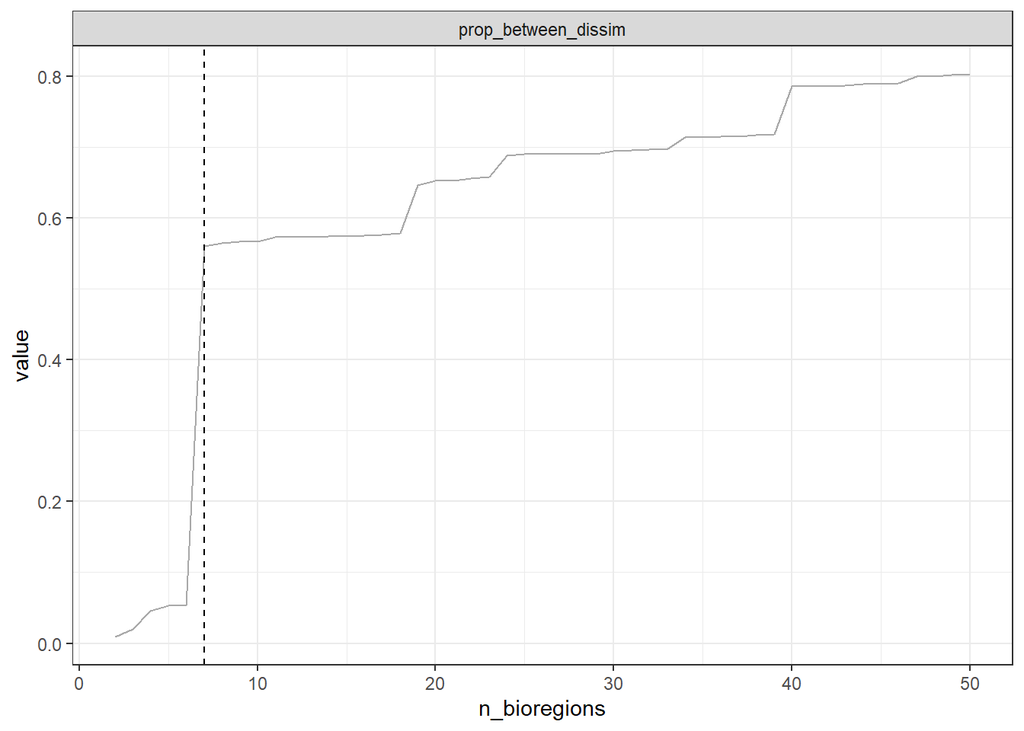

```r
hclust_araignees_50 <- cut_tree(hclust_araignees_50,
                               n_clust = optimal_n_50$optimal_n[[1]])
```

```
## Determining the cut height to reach 7 groups...
```

```
## --> 0.7109375
```

```r
summary(hclust_araignees_50)
```

```
##
## Summary of clustering results
## =============================
##
## Algorithm:  hclu_hierarclust
## Number of sites:  742
## Number of bioregionalizations:  1
## Hierarchical clustering: No
##
## Bioregionalization 1: K_7
## -------------------------
## Total clusters:  7
## Top 7 clusters by size:
##   Cluster 1: 508 items
##   Cluster 4: 220 items
##   Cluster 5: 7 items
##   Cluster 3: 3 items
##   Cluster 7: 2 items
##   Cluster 2: 1 items
##   Cluster 6: 1 items
```

**Question** Combien de clusters pour chaque arbre ? A quelle hauteur l’arbre a-t-il été coupé ?

Sur le jeu de données complet, nous obtenons 41 clusters, et la hauteur de coupe est de 0.771. Sur le jeu de données filtré, nous obtenons 7 clusters, et la hauteur de coupe est de 0.711. La fonction `summary()` permet d’afficher la hiérarchie des clusters de manière claire.

# 7. Faire la carte des clusters obtenus

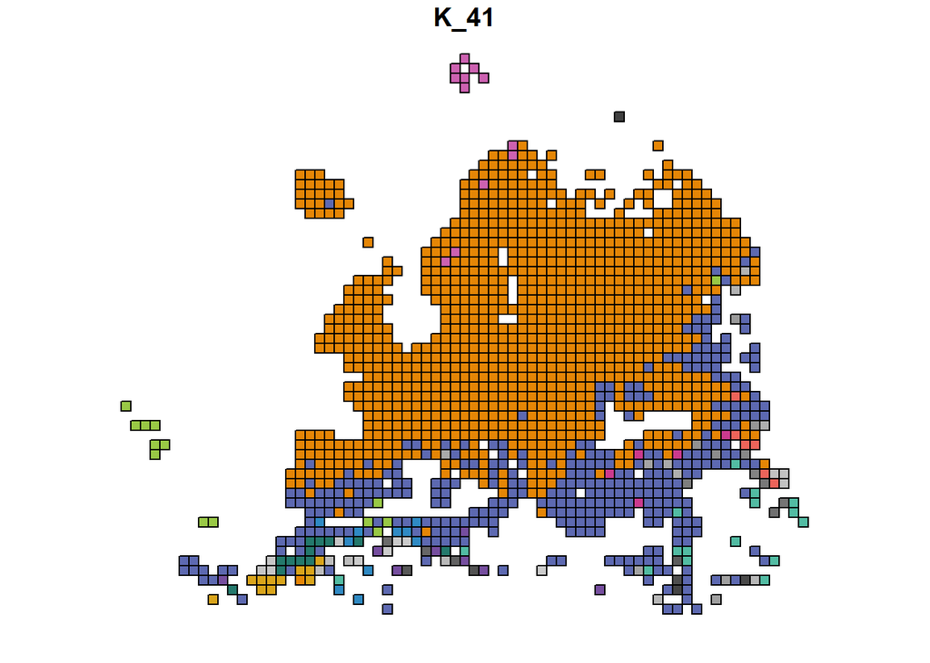

```r
# Ajouter automatiquement des couleurs aux clusters
hclust_colored <- bioregion_colors(hclust_araignees)


map_bioregions(bioregionalization = hclust_colored,
               map = sites,
               partition_index = 2)
```

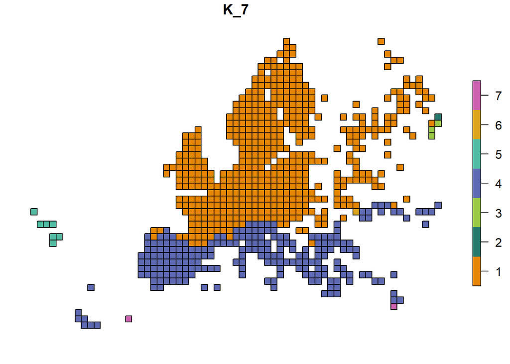

```r
hclust_colored_50 <- bioregion_colors(hclust_araignees_50,
                                      palette = "Vivid",
                                      cluster_ordering = "n_sites")

map_bioregions(bioregionalization = hclust_colored_50,
               map = sites_50,
               partition_index = 2)
```

Décrivez le résultat que vous obtenez :

- Semble-t-il y avoir différents clusters ?

Pour le jeu filtré, le signal devient très clair, avec deux grands clusters et quelques petits.

- Comment sont-ils distribués ?

- Fallait-il filtrer ou non le jeu de données pour éliminer les cellules à faible richesse ? Pourquoi ?

Oui. Les cellules pauvres sont surtout sous-échantillonnées. Elles partagent peu d’espèces avec les autres et forment de nombreux petits clusters sans sens biologique. Après filtrage, l’arbre est de meilleure qualité et les régions sont interprétables. En contrepartie, on perd les régions mal échantillonnées (Afrique du Nord, Moyen-Orient, Russie).

# 8. Comparaison avec la méthode des réseaux (jeu complet)

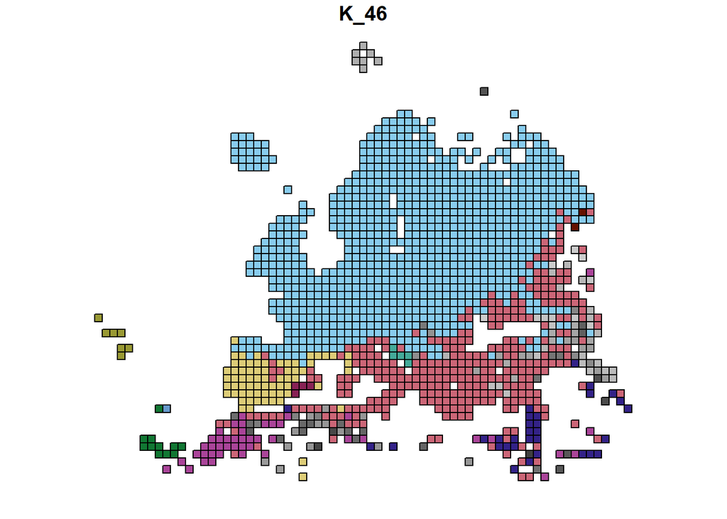

```r
# Conversion de la matrice en réseau sites - espèces
net_araignees <- mat_to_net(comat)

araignees_infomap <- netclu_infomap(net = net_araignees,
                                    weight = FALSE,
                                    binpath = "c:/r",
                                    numtrials = 100,
                                    show_hierarchy = TRUE,
                                    bipartite = TRUE,
                                    bipartite_version = FALSE,
                                    seed = 123)

araignees_infomap <- bioregion_colors(araignees_infomap,
                                      palette = "Safe",
                                      cluster_ordering = "n_both")

map_bioregions(bioregionalization = araignees_infomap,
               map = sites,
               partition_index = 2)
```

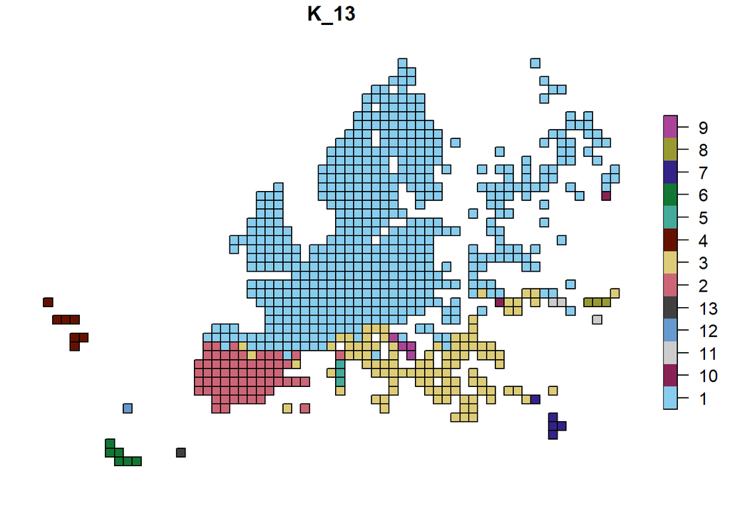

```r
net_araignees_50 <- mat_to_net(comat_50)

araignees_infomap_50 <- netclu_infomap(net = net_araignees_50,
                                    weight = FALSE,
                                    binpath = "c:/r",
                                    numtrials = 100,
                                    show_hierarchy = TRUE,
                                    bipartite = TRUE,
                                    bipartite_version = FALSE,
                                    seed = 123)

araignees_infomap_50 <- bioregion_colors(araignees_infomap_50,
                                         palette = "Safe",
                                         cluster_ordering = "n_both")

map_bioregions(bioregionalization = araignees_infomap_50,
               map = sites_50,
               partition_index = 2)
```

La méthode des réseaux détecte des clusters cohérents même sur le jeu de données non filtré, malgré beaucoup de bruit dans les données. On observe ainsi des clusters insulaires, différents clusters méditerranéens reflétant divers refuges glaciaires, etc. sans avoir été obligé de filtrer tout le jeu de données. La version filtrée donne des résultats encore plus nets, mais omet beaucoup de zones avec des déficits de connaissance.